# Board games

Autumn 2025

## Board Gaming

**Everything you need to know for a workshop exercise and for set exercises**

And play board games, because board games rule!

## What is a board game?

- A game that is played on a board
- Typically includes pieces which are moved around the board.
- May also include cards and dice which modify gameplay

[figure not shown]

## Monopoly

- “It is a boring game…” – Dr Longford
- Has a strong theme…

  capitalism sucks
- Uses pieces, cards and dice.

## Player movement

No freedom of movement; player moves clockwise based on dice roll.

[figure not shown]

[figure not shown]

[figure not shown]

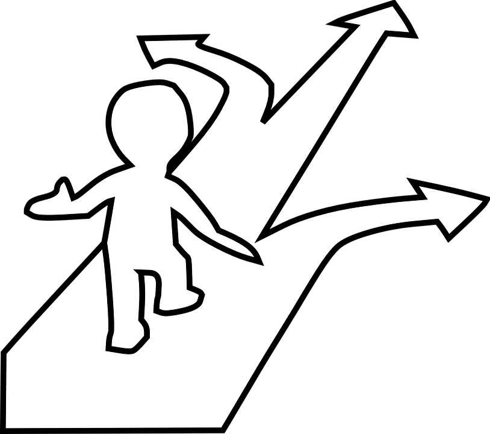

## Player choice

- Land on a location: player can purchase it and place houses / hotels.
  - The only sensible thing to do is buy.
- Two types of cards, in piles: player takes from the top if they land on appropriate square.
  - Cards give instructions
  - “Get out of jail free” card can be saved for later, all others apply immeditely.

## Themes and Mechanics

- Theme should fit mechanics as much as possible
  - **Theme**
    - The setting of the game: e.g. prehistoric, WW2, post-apocalyptic…
  - **Mechanics**
    - The rules of the game: how combat resolves, how players move…
- Re-skinning an existing game, e.g., many variations of Monopoly (everyone knows London is the only Monopoly) is not creating a new game!

## Examples

- **Survival**
  - Resource management
  - Health or statistics bar to monitor character progress
- **Horror**
  - Bravery meter
  - Random events
- **War games**
  - Shooting or combat mechanics – cards or dice
  - Negotiation or dynamic teams

## Boards

- Controls movement
- Created / built by players, or provide options, or set out a fixed path.
- Common types of board:
  - Square boards (chess)
  - Hex boards (allowing maximum range of movement

[figure not shown]

## Ticket to ride

- A railway building board game
- Series of preset routes represented by colours. You collect cards of various colours then use them to “buy” connections between places

[figure not shown]

[figure not shown]

[figure not shown]

## Happy little dinosaurs

- Game about the end of the world!
- You play a cute little dinosaur that struggles with life and just wants to run away

[figure not shown]

[figure not shown]

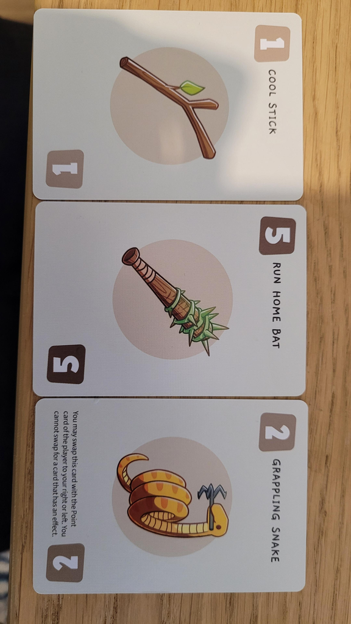

[figure not shown]

## Memoir 44

- WW2 strategy game based on hex movement.
- Based on real historical battles…

  …so each game might have unbalanced sides!
- Short games, so players can try both sides.

[figure not shown]

[figure not shown]

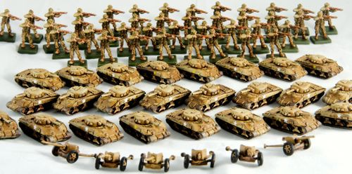

[figure not shown]

## Combat

- Decided by dice rolls
- The type of unit affects its range
  - Infantry: shoot 3 hexes but number of dice used decrase by 1 for each hex
  - Tanks have a range of 3 and do not decrease by range
- Damage is defined by dice roll
- Terrain further modifies the number of dice you can use for combat depending on your unit type

[figure not shown]

[figure not shown]

## Diplomacy

- Social cooperation game based on wars between European powers in 1901.
- Moves are made simultaneously: orders are written down, then carried out
- Based around making and breaking deals with other players

[figure not shown]

[figure not shown]

## Bolt Action

- Miniatures game where players buy, build and paint armies.
- Battles based around reinforced infantry platoons with riflemen, machine gunners, tanks, and artillary.
- Random turn order (different from warhammer)

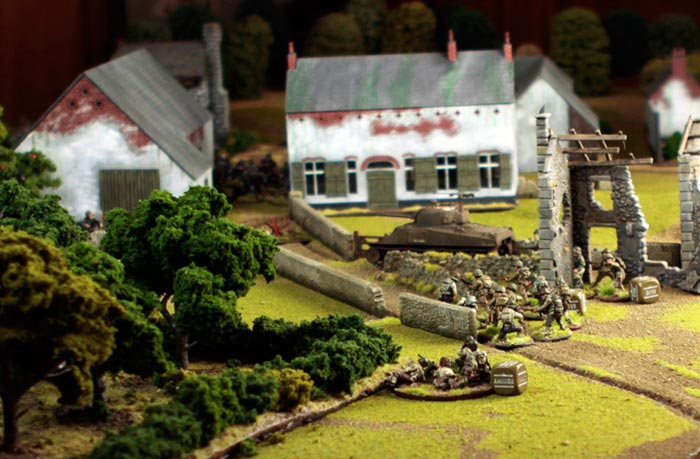

## Dice movement randomness

[figure not shown]

[figure not shown]

[figure not shown]

Bolt action movement is defined by unit type:

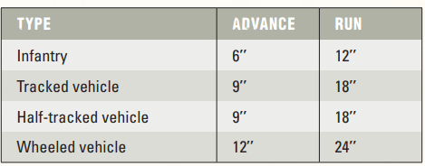

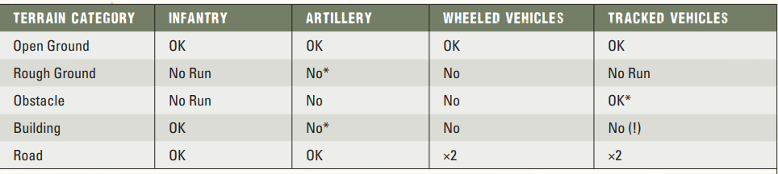

## Moral system

- Many war games have a “feel bad” mechanic

  if you don’t score hits / wounds then your turn is “wasted”.
- In bolt action, every time you hit a unit, they take a “pin” reguardless of whether they are wounded
- For each “pin” a unit has, there is a \(n – 1\) score to a moral check. i
- If the unit fails a check it can’t make any actions!

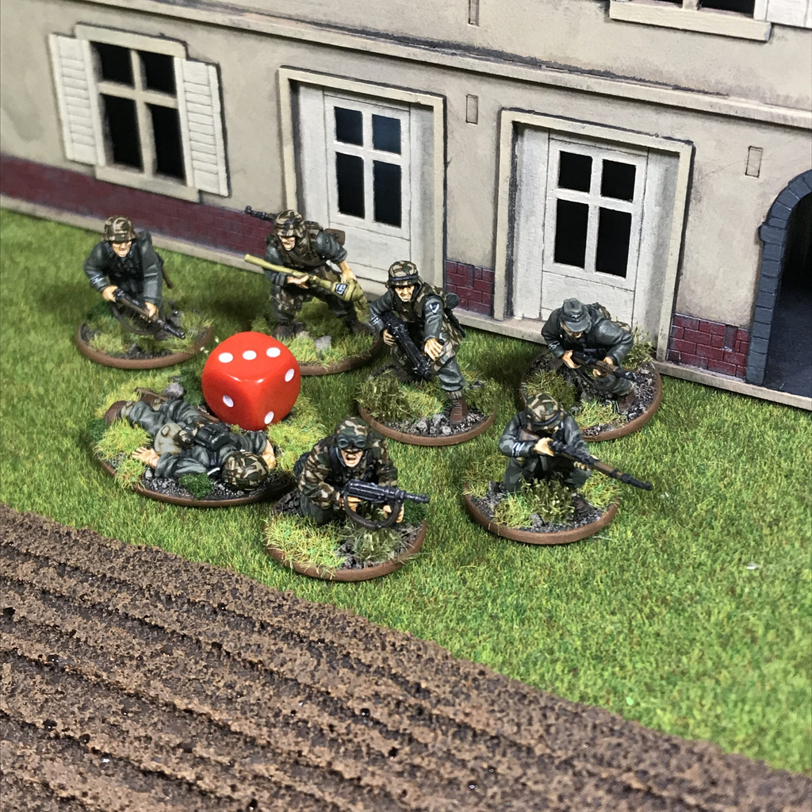

[figure not shown]

## Pandemic

- A Cooperative game!
- Each player has a different skill, and they have to work together to prevent a disease whiping out the world!

[figure not shown]

## The Next Group Challenge

- Design either a board game or a wargame with cards and dice
- Use as many of these as you like
- Design the game, then work out the probabilities of dice rolls / card draws.
- Based on your findings, decide how fair your game is, using probability